# TOPIC

Dynamische und reproduzierbare Berichte mit R

Autor:in

Zugehörigkeit

Daniela Palleschi

Humboldt-Universität zu Berlin

Veröffentlichungsdatum

26. Juni 2023

# Aufgabenübersicht

Für diesen Bericht werden Sie Diagramme interpretieren, Daten einlesen und verarbeiten und 2 Tabellen und 2 Diagramme erstellen.

# Beabsichtigte Lernergebnisse

- Das beabsichtigte Ziel dieses Berichts ist es, dass Sie nachweisen:

### Kenntnisse und Fähigkeiten

- die Fähigkeit, zusammenfassende Statistiken zu berechnen
- die Fähigkeit, Tabellen mit zusammenfassenden Statistiken und Datenverteilungen zu erstellen

### Kommunikation

- die Fähigkeit, formatierte Tabellen mit zusammenfassenden Statistiken zu drucken
- die Fähigkeit, Unterschiede zwischen Datengruppen durch Bezugnahme auf zusammenfassende Statistiken und Diagramme zu beschreiben

# Bewertung

Die Bewertung erfolgt auf der Grundlage der Replikation der

- die Struktur des Dokuments (die HTML-Ausgabe)
- die Struktur und Genauigkeit des Codes (`.qmd`-Quellcode)
- die Ähnlichkeit zwischen den Originalplots und Ihren Plots

## Tipps

Einige Tipps:

- Sie können auf Deutsch oder Englisch schreiben, je nachdem, was Sie bevorzugen
- Ich empfehle Ihnen dringend, Ihr Dokument *oft* zu rendern! Auf diese Weise können Sie, wenn ein Problem auftaucht, besser einschätzen, welcher Code es verursacht.
- Wenn Sie das Gefühl haben, dass Sie etwas langsam sind, versuchen Sie, sich auf das “große Ganze” zu konzentrieren und machen Sie sich keine Gedanken über all die Details in den Plots
  - Versuchen Sie zunächst, den Plot im Allgemeinen zu erstellen, und gehen Sie dann zu den Details über
  - Ich persönlich würde zuerst versuchen, die Handlung im Großen und Ganzen zu entwerfen, und mich dann um die Details kümmern

*Tun Sie einfach Ihr Bestes!*

## Biondo, Soilemezidi, und Mancini (2022): Verarbeitung der Kongruenz der Zeitformen der Verben

Unsere Daten stammen aus einem Eye-Tracking-Experiment von Biondo, Soilemezidi, und Mancini (2022), bei dem:

- Die Teilnehmer lasen (spanische) Sätze mit Zeitformeln aus der Vergangenheit oder Zukunft (z. B. *ayer* ‘gestern’ oder *mañana* ‘morgen’) und Verbformen aus der Vergangenheit oder Zukunft (z. B. *compraron* ‘gekauft’ oder *comprarán* ‘wird kaufen’). In Abbildung 1 finden Sie Beispielsätze in der Vergangenheit und in der Zukunft unter grammatikalischen (“match”) und ungrammatikalischen (“mismatch”) Bedingungen.
- Die Augenbewegungen wurden aufgezeichnet, während die Teilnehmer die Sätze lasen
- Die Haupthypothese: Wenn die Temporalphrasen nicht mit der Verbform übereinstimmen (z.B. ‘gestern…kaufen’ oder ‘morgen…kaufen’), sollten *längere* Lesemaßnahmen in der Verbregion beobachtet werden.
- Eine weitere Frage: Wird dieser Effekt sowohl für die Vergangenheit als auch für die Zukunft beobachtet?

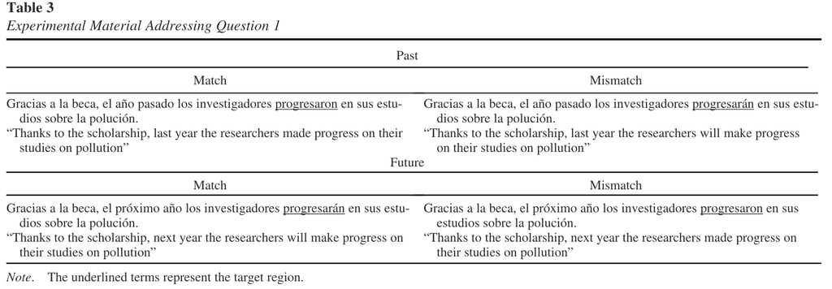

Abbildung 1: Beispielsätze aus Biondo, Soilemezidi, und Mancini (2022)

## Variablen

Unsere **Messvariablen** (d. h. abhängige Variablen) sind drei eye-tracking Messungen der Lesezeit:

- Lesezeit beim ersten Durchgang (*first-pass reading time*: Summe aller Fixierungen auf einer Region von Interesse, bevor diese entweder nach links oder nach rechts verlassen wird)
- Regressionspfaddauer (*regression path duration*: Summe des ersten Durchlaufs plus der Zeit, die für das erneute Lesen früherer Regionen aufgewendet wird, bevor die Region von Interesse passiert wird)
- Gesamtlesedauer (*total reading time*: die Gesamtzeit, die beim Lesen des Satzes auf das Verb geschaut wird)

Unsere **Prädiktorvariablen** (d. h. unabhängige Variablen) sind:

- die *Temporaladverb Zeitbezug* (Vergangenheit oder Zukunft)
- die *Verbform* (*tense*) (Vergangenheit oder Zukunft)
- die *Satzregion* (Adverb oder Verb)

## Vorhersagen

In der Regel gehen wir davon aus, dass längere Lesezeiten auf *Verarbeitungsschwierigkeiten*, d. h. Schwierigkeiten bei der Sprachverarbeitung, hinweisen. Die Hypothese war daher, dass längere Lesezeiten für die *Verb*-Region in ungrammatischen Sätzen vorhanden sein würden. Diese Frage werden wir heute mit den Daten nicht beantworten können.

# 1 Einrichten

## 1.1 YAML

- Erstellen Sie ein neues Quarto-Dokument
- Stellen Sie sicher, dass Ihre YAML enthält:
  - einen passenden Titel
  - Ihren Vor- und Nachnamen (`author`)
  - das Datum
  - das Inhaltsverzeichnis
  - unter `format: html`…, `self-contained: true` einfügen
    - und setzen Sie die globalen Chunk-Optionen auf `echo: false`
- Ihr YAML sollte etwa so aussehen

```r
---
title: "Summary assignment: wrangling and data viz"
subtitle: "In-class assignment 1"
author: "YOUR NAME HERE"
institute: Humboldt-Universität zu Berlin
lang: de
date: "`r Sys.Date()`"
format:
  html:
    toc: true
    number-sections: true
    self-contained: true
    execute:
      echo: false
---
```

## 1.2 Struktur des Dokuments

- Sie werden Ihr Quarto-Skript und die HTML-Ausgabe Ihres Skripts einreichen.
- Um die Lesbarkeit des gerenderten Dokuments zu verbessern, sollten Sie das Dokument durch Überschriften und Zwischenüberschriften strukturieren.
- Verwenden Sie schriftlichen Text, wo es notwendig ist, um Fragen zu beantworten/ Prozesse zu beschreiben
- Verwenden Sie bei Bedarf Code-Bausteine
- eine gute Strategie für die Wahl einer Überschrift: Wenn dieses Dokument einen neuen Abschnitt enthält, sollten Sie auch einen neuen Abschnitt erstellen

## 1.3 Pakete

- werden Sie die Pakete benötigen:
  - `tidyverse`
  - `here`
  - `janitor`
  - `devtools`
  - `knitr`
  - `kableExtra`

Laden Sie sie mit dem Paket `pacman` (Funktion `p_load()`).

```r
pacman::p_load(tidyverse,
               here,
               janitor,
               devtools,
               knitr,
               kableExtra)
```

## 1.4 Datenbeschreibung

1. Laden Sie den Datensatz `Biondo_etal_2021_bericht2.csv` aus Moodle herunter, und speichern Sie ihn im Ordner `daten`.
2. Dann laden Sie die Daten und verwenden die Funktion `clean_names()` aus dem Paket `janitor`, um die Variablennamen zu bereinigen.

Unsere Variablen sind in Tabelle 1 beschrieben.

```r
df_biondo <- read_csv(here("daten", "Biondo_etal_2021_bericht2.csv")) %>%
  janitor::clean_names()
```

Tabelle 1: Variable names and descriptions for dataset Biondo_etal_2021_bericht2.csv

| variable | type | description |
| --- | --- | --- |
| subj | numeric | Participant ID |
| item_num | numeric | Item number |
| label | character | sentence region text |
| total_time | numeric | total reading time in milliseconds (eye-tracking: sum of all fixations made on a region of interest during the trial) |
| adverb_time | character | adverb time reference: past/future |
| gramm | numeric | grammaticality: whether the adverb time and verb tense matched (0: ungrammatical, 1: grammatical) |
| verb_tense | character | verb tense: past/future |
| first_pass | numeric | first-pass reading time in milliseconds (eye-tracking: sum of all fixations on a region of interest before leaving it either to the left or to the right |
| regression_path | numeric | regression path duration/go-past time (eye-tracking: sum of the first-pass plus the time spent rereading previous regions before moving past the region of interest) |
| regress_in | numeric | regression in; 0 = no, 1 = yes (eye-tracking: whether the region received a regression) |
| regress_out | numeric | regression out; 0 = no, 1 = yes (eye-tracking: whether a regression out of the region was made) |
| region | character | sentence region; here we only have adverb/verb |

# 2 Data wrangling

1. Ordnen (d.h., `arrange()`) Sie die Daten nach Thema, Positionsnummer und Region, `und dann`,
2. Herausfiltern (d.h. `filter()`) von Beobachtungen, bei denen `adverb_time` `none` ist, `and then`,
3. Ordne die Variablen neu an (d.h. `relocate()`), so dass sie in der folgenden Reihenfolge stehen:
   - `subj`, `item_num`, `region`, `label`, `adverb_time`, `verb_tense`, `gramm`, `first_pass`, `regression_path`, `total_time`, `regress_in`, `regress_out`
2. Drucken Sie die ersten 10 Zeilen Ihres Datenrahmens mit den Funktionen `kable()` und `kable_styling()`. Dies sollte wie Tabelle 2 aussehen.

```r
df_biondo %>%
  head(n = 10) %>%
  kable() %>%
  kable_styling()
```

Tabelle 2: First 10 rows of df_biondo after data wrangling

| subj | item_num | region | label | adverb_time | verb_tense | gramm | first_pass | regression_path | total_time | regress_in | regress_out |
| --- | --- | --- | --- | --- | --- | --- | --- | --- | --- | --- | --- |
| 1 | 1 | adverb | mañana | Future | Future | 1 | 453 | 453 | 453 | 0 | 0 |
| 1 | 1 | verb | representarán | Future | Future | 1 | 1596 | 1596 | 1596 | 0 | 0 |
| 1 | 2 | adverb | el próximo domingo | Future | Future | 1 | 782 | 782 | 782 | 0 | 0 |
| 1 | 2 | verb | alzarán | Future | Future | 1 | 316 | 316 | 648 | 1 | 0 |
| 1 | 3 | adverb | el mes que viene | Future | Future | 1 | 614 | 614 | 614 | 0 | 0 |
| 1 | 3 | verb | centrarán | Future | Future | 1 | 238 | 1810 | 841 | 0 | 1 |
| 1 | 4 | adverb | el próximo año | Future | Future | 1 | 593 | 593 | 1356 | 1 | 0 |
| 1 | 4 | verb | coleccionarán | Future | Future | 1 | 562 | 562 | 1337 | 1 | 0 |
| 1 | 5 | adverb | mañana a la una | Future | Future | 1 | 726 | 726 | 1007 | 1 | 0 |
| 1 | 5 | verb | complementarán | Future | Future | 1 | 195 | 1758 | 1400 | 0 | 0 |

## 2.1 Data tidying

1. Erstellen Sie eine längere Version des Datensatzes, so dass die Namen der Spalten `first_pass`, `regression_path` und `total_time` in einer neuen Variablen `measure` und ihre Werte in einer neuen Variablen `time` gespeichert werden. Sie müssen die Funktion `pivot_longer()` verwenden.
2. Drucken Sie die ersten zehn Zeilen des neuen Datenrahmens mit den Funktionen `kable()` und `kable_styling()`. Es sollte wie Tabelle 3 aussehen.

```r
df_biondo_long %>%
  head(n = 10) %>%
  kable() %>%
  kable_styling()
```

Tabelle 3: First 10 rows of df_biondo_longer

| subj | item_num | region | label | adverb_time | verb_tense | gramm | measure | time | regress_in | regress_out |
| --- | --- | --- | --- | --- | --- | --- | --- | --- | --- | --- |
| 1 | 1 | adverb | mañana | Future | Future | 1 | first_pass | 453 | 0 | 0 |
| 1 | 1 | adverb | mañana | Future | Future | 1 | regression_path | 453 | 0 | 0 |
| 1 | 1 | adverb | mañana | Future | Future | 1 | total_time | 453 | 0 | 0 |
| 1 | 1 | verb | representarán | Future | Future | 1 | first_pass | 1596 | 0 | 0 |
| 1 | 1 | verb | representarán | Future | Future | 1 | regression_path | 1596 | 0 | 0 |
| 1 | 1 | verb | representarán | Future | Future | 1 | total_time | 1596 | 0 | 0 |
| 1 | 2 | adverb | el próximo domingo | Future | Future | 1 | first_pass | 782 | 0 | 0 |
| 1 | 2 | adverb | el próximo domingo | Future | Future | 1 | regression_path | 782 | 0 | 0 |
| 1 | 2 | adverb | el próximo domingo | Future | Future | 1 | total_time | 782 | 0 | 0 |
| 1 | 2 | verb | alzarán | Future | Future | 1 | first_pass | 316 | 1 | 0 |

# 3 Plot-Interpretation

In diesem Abschnitt werden Sie verschiedene Arten von Diagrammen interpretieren. Tipp: Lesen Sie immer zuerst den Titel und/oder die Beschriftung einer Tabelle und sehen Sie sich an, was die y- und x-Achse darstellen, sowie alle anderen ästhetischen Merkmale (z. B. die Farbe).

## 3.1 Distributions

1. Vergleichen Sie den Code für `fig_1`, `fig_2` und `fig_3` mit der Ausgabe von Abbildung 2. Welcher Code ergibt A, B, und C? Wie konnen Sie das erkennen?

```r
fig_1 <-
  df_biondo_long %>%
  ggplot(aes(x = time, fill = verb_tense, colour = verb_tense)) +
  labs(colour = "Tense",
       fill = "Tense") +
  facet_wrap(~region) +
  geom_histogram(alpha = .2)  +
  theme_bw()
```

```r
fig_2 <-
  df_biondo_long %>%
  ggplot(aes(x = time, fill = verb_tense, colour = verb_tense)) +
  labs(x = "Time (ms)",
       y = "Number of observations") +
  facet_wrap(~measure) +
  geom_histogram(alpha = .2) +
  theme_bw()
```

```r
fig_3 <-
  df_biondo_long %>%
  ggplot(aes(x = time, y = adverb_time, fill = verb_tense, colour = verb_tense)) +
  labs(x = "Time (ms)",
       y = "Adverb time reference") +
  facet_wrap(~measure) +
  geom_boxplot(alpha = .2) +
  theme_bw()
```

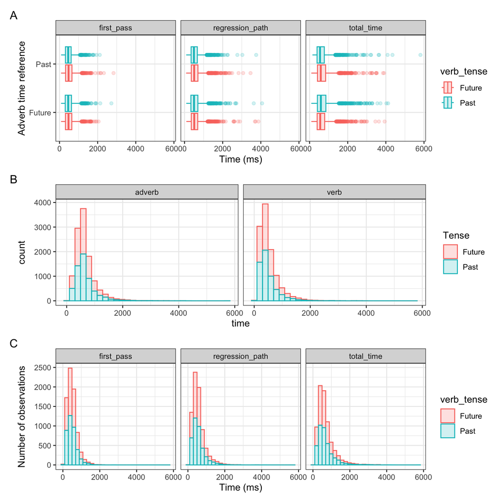

## 3.2 Zusammenfassende Statistiken

1. Schau dir Abbildung 3 an.
   - Welche drei `geom` werden benötigt, um diese Darstellung zu erstellen?
   - Was stellt das linke obere Feld dar (z. B. Maßnahme, Satzregion)?
   - Welche Verbform hatte eine längere Regressionspfaddauer in der Verbregion?
   - Beschreiben Sie das Muster der Gesamtlesezeit in der Verbregion (d. h., welche Unterschiede stellen Sie zwischen den Bedingungen fest?).

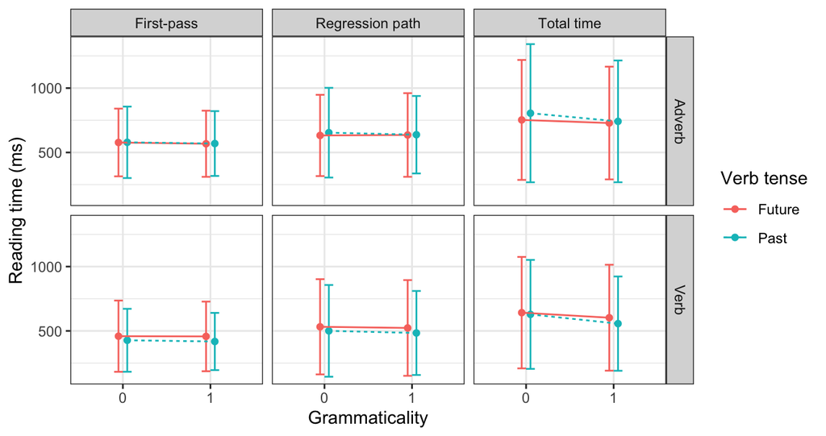

Abbildung 3: Mean reading times per condition (with +/- 1SD)

# 4 Data summaries

Tabelle 4: Mean and standard deviations per region and condition

| region | adverb_time | verb_tense | measure | N | mean | sd |
| --- | --- | --- | --- | --- | --- | --- |
| adverb | Future | Future | first_pass | 953 | 567.6107 | 257.1014 |
| adverb | Future | Past | first_pass | 953 | 578.6967 | 277.6434 |
| adverb | Future | Future | regression_path | 953 | 635.6002 | 324.8907 |
| adverb | Future | Past | regression_path | 953 | 653.6128 | 348.4972 |
| adverb | Future | Future | total_time | 953 | 728.5278 | 437.8639 |
| adverb | Future | Past | total_time | 953 | 804.8374 | 536.7249 |
| adverb | Past | Past | first_pass | 954 | 569.2610 | 251.8370 |
| adverb | Past | Future | first_pass | 953 | 577.3820 | 263.0772 |
| adverb | Past | Past | regression_path | 954 | 637.8847 | 300.9607 |
| adverb | Past | Future | regression_path | 953 | 632.0588 | 315.7681 |
| adverb | Past | Past | total_time | 954 | 741.4140 | 473.1569 |
| adverb | Past | Future | total_time | 953 | 752.6306 | 465.9965 |
| verb | Future | Future | first_pass | 948 | 457.4409 | 270.6509 |
| verb | Future | Past | first_pass | 945 | 427.3079 | 244.4802 |
| verb | Future | Future | regression_path | 948 | 523.1719 | 371.8651 |
| verb | Future | Past | regression_path | 945 | 500.5524 | 356.4027 |
| verb | Future | Future | total_time | 948 | 602.7521 | 411.5918 |
| verb | Future | Past | total_time | 945 | 628.4836 | 423.4241 |
| verb | Past | Past | first_pass | 953 | 417.9307 | 222.3428 |
| verb | Past | Future | first_pass | 949 | 459.2160 | 276.7817 |
| verb | Past | Past | regression_path | 953 | 484.0598 | 326.3804 |
| verb | Past | Future | regression_path | 949 | 532.1349 | 369.9950 |
| verb | Past | Past | total_time | 953 | 556.7817 | 366.4723 |
| verb | Past | Future | total_time | 949 | 642.0242 | 433.0259 |

# 5 Plotten der Daten

In diesem Abschnitt werden Sie 2 Diagramme erstellen.

## 5.1 Verteilungen

1. Erzeugen Sie Abbildung 4. Du musst verwenden:
   - `df_biondo_long`
   - `filter()` (nur Verbregion)
   - 2 `geom`s
   - `facet_wrap(~)`
   - `labs()`
   - `position_jitterdodge()`
   - `alpha =` (zur Kontrolle der Transparenz eines Geoms)

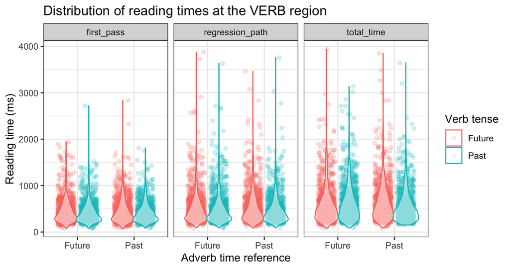

Abbildung 4: Violin-scatterplot

## 5.2 Split-violin plots

Für diese Aufgabe werden Sie eine neue Art von Diagramm erstellen: das Split-Violine-Diagramm. Dies ist derzeit nicht einfach mit `ggplot2` zu machen, also müssen wir ein neues Paket installieren: `introdataviz`. Dieses Paket begleitet Nordmann u. a. (2022), und hat auch ein [Online-Tutorial](https://psyteachr.github.io/introdataviz/advanced-plots.html).

1. Installieren Sie `introdataviz` (dies funktioniert nur, wenn Sie bereits das Paket `devtools` mit `pacman::p_load()` am Anfang dieses Skripts installiert/geladen haben)

```r
# how to install the introdataviz package to get split and half violin plots
devtools::install_github("psyteachr/introdataviz")
```

2. Einladen von `Introdataviz`

```r
library(introdataviz)
```

3. Erstellen Sie eine mehrschichtige Darstellung mit:
   - Datenrahmen `df_biondo_long`
   - Zeit” auf der y-Achse
   - `verb_tense` auf der x-Achse
   - `gramm` `colour` und `fill` (Achtung: `gramm` muss `as_faktor()` gelesen werden)
   - Messung” in `facet_wrap(~)`
   - split-violin plot (`geom_split_violin()` aus `introdataviz`)
   - Boxplot (`Geom_boxplot()` aus `ggplot2`)

Tipp: Die Erstellung dieses Diagramms erfolgt auf genau dieselbe Weise, als ob Sie einfach `geom_violin()` anstelle von `geom_split_violin()` verwenden würden, um ein Violin-Boxplot-Diagramm zu erstellen.

3. Korrigieren Sie dann die Beschriftungen und passen Sie die Transparenz des `geom`s an (mit `alpha()`), so dass es ähnlich aussieht wie Abbildung 5.

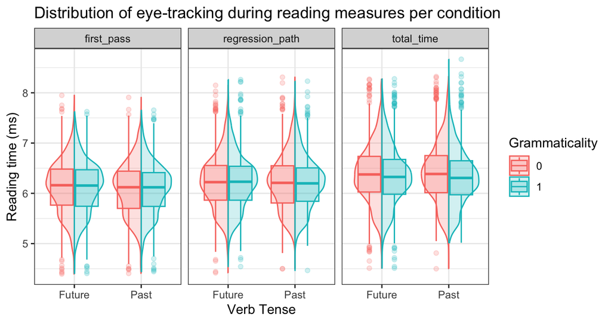

Abbildung 5: A split-violin boxplot

# 6 Code-Chunk-Optionen

Für diesen Bericht haben Sie zwei Tabellen gedruckt und zwei Diagramme erstellt. Wenn Sie dies noch nicht getan haben, erstellen Sie entsprechende Beschriftungen (`#| label: tbl-` oder `fig-`) und Überschriften (`tbl-cap:` oder `fig-cap:`) für diese Tabellen und Abbildungen.

# 7 Session Info einbeziehen

Am Ende Ihres Berichts:

Wenn Sie nun Ihr Dokument rendern, sollte eine Zusammenfassung der geladenen Pakete und ihrer Versionen angezeigt werden.

# 8 Bericht einreichen

Wenn Sie fertig sind, laden Sie Ihr `.qmd`-Skript *und* die gerenderte Ausgabe im HTML-Format in Moodle hoch.

# Session Info

Hergestellt mit R version 4.3.0 (2023-04-21) (Already Tomorrow) und RStudioversion 2023.3.0.386 (Cherry Blossom).

# Literaturverzeichnis

Biondo, Nicoletta, Marielena Soilemezidi, und Simona Mancini. 2022. „Yesterday Is History, Tomorrow Is a Mystery: An Eye-Tracking Investigation of the Processing of Past and Future Time Reference During Sentence Reading.“ *Journal of Experimental Psychology: Learning, Memory, and Cognition* 48 (7): 1001–18. https://doi.org/10.1037/xlm0001053.

Nordmann, Emily, Phil McAleer, Wilhelmiina Toivo, Helena Paterson, und Lisa M. DeBruine. 2022. „Data Visualization Using R for Researchers Who Do Not Use R“. *Advances in Methods and Practices in Psychological Science* 5 (2): 251524592210746. https://doi.org/10.1177/25152459221074654.